# Statistical Inference Course Project

jbassard

Jully 20th 2017

# Overview

This is the project for the statistical inference class on corusera. In it, we will investigate the exponential distribution in R and compare it with the Central Limit Theorem and we will do some simple inferential data analysis. The project consists of two parts:

Part 1 - A simulation exercise. Part 2 - Basic inferential data analysis.

### Setup directory and load necessary packages:

```r
if(!file.exists("./StatisticalInf")) {
    dir.create("./StatisticalInf")}
setwd("./StatisticalInf")
if (!require("knitr")) {
    install.packages("knitr")}
library(knitr)
```

### Setting the default of echo and cache to be True throughout the whole report

```r
knitr::opts_chunk$set(echo = TRUE)
knitr::opts_chunk$set(cache=TRUE)
```

## Part 1: Simulation Exercise

In this exercise we will investigate the exponential distribution in R and compare it with the Central Limit Theorem. The exponential distribution is simulated in R with rexp(n, lambda) where lambda is the rate parameter. The mean of exponential distribution is 1/lambda and the standard deviation is also 1/lambda. We set lambda = 0.2 for all of the simulations. We will investigate the distribution of averages of 40 exponentials. We will need to do a thousand simulations.

### Setting up the simulation

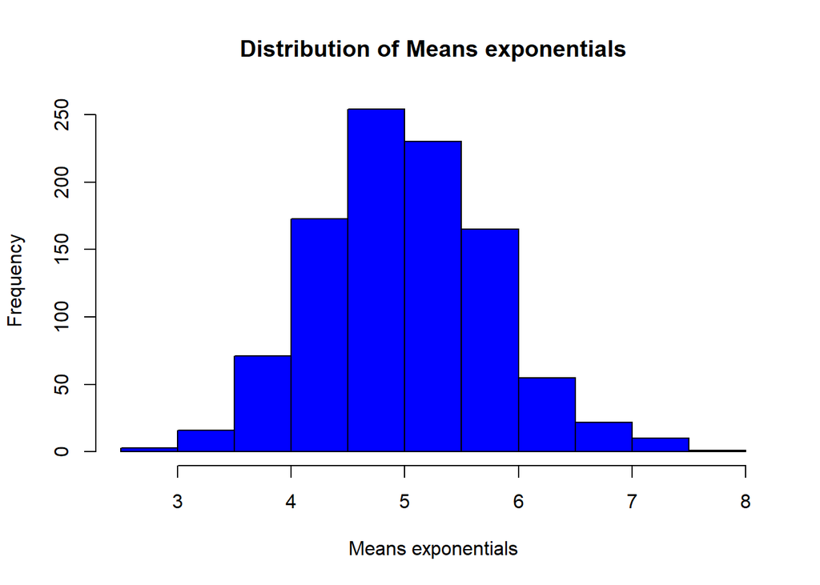

```r
set.seed(2701) # set seed for reproducability of the simulation
lambda <- 0.2 # set lambda to 0.2
n <- 40 # sample size equal to 40
sim <- 1000 # 1000 simulations
simulated_exponentials <- replicate(sim, rexp(n, lambda)) # do the simulation
means_exponentials <- apply(simulated_exponentials, 2, mean) # iteratively calculate means of the exponentials
hist(means_exponentials, xlab = "Means exponentials", main = "Distribution of Means exponentials", col="blue") # display the distribution of the means
```

###Question 1: Show the sample mean and compare it to the theoretical mean of the distribution

```r
sample_mean <- mean(means_exponentials) # calculation of the sample mean
print(paste("Sample mean =", round(sample_mean, 4)))
```

```
## [1] "Sample mean = 4.9996"
```

```r
theoretical_mean <- 1/lambda # calculation of the theoretical mean
print(paste("Theoretical mean of the distribution =", round(theoretical_mean, 4)))
```

```
## [1] "Theoretical mean of the distribution = 5"
```

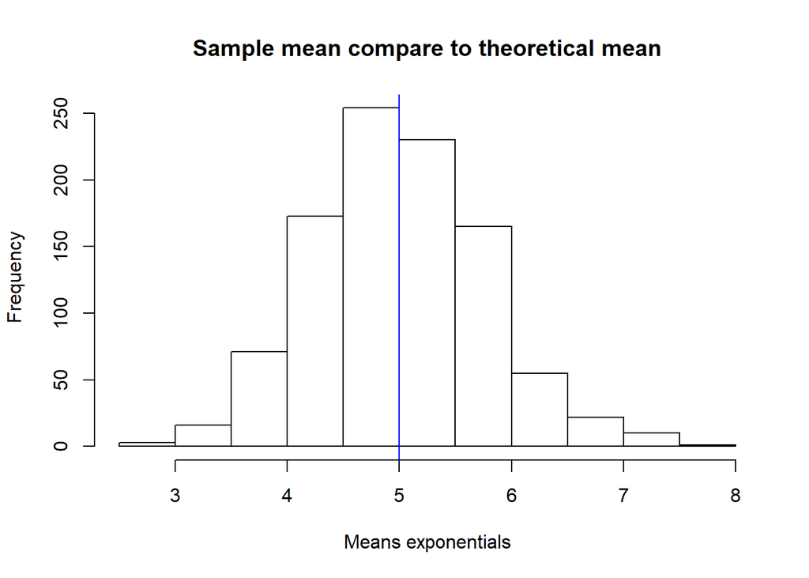

```r
hist(means_exponentials, xlab = "Means exponentials", main = "Sample mean compare to theoretical mean")
abline(v = sample_mean, col = "red") ; abline(v = theoretical_mean, col = "blue")
```

The sample mean is 4.9996215 and the analytical mean is 5. Thus, the center of distribution of averages of 40 exponentials is very close to the theoretical center of the distribution and not distinguishable on the graphic.

### Question 2: Show how variable the sample is (via variance) and compare it to the theoretical variance of the distribution

```r
distribution_var <- round(var(means_exponentials), 4) # calculation of the variance from the simulation distribution
theoretical_var <- ((1/lambda)*(1/sqrt(n)))^2 # calculation of the theoretical variance

print (paste("Variance based on the simulations = ", distribution_var))
```

```
## [1] "Variance based on the simulations =  0.5795"
```

```r
print (paste("Theoretical variance = ", theoretical_var))
```

```
## [1] "Theoretical variance =  0.625"
```

Theoretical variance is larger thant variance based on simulations.

### Question 3: Show that the distribution is approximately normal

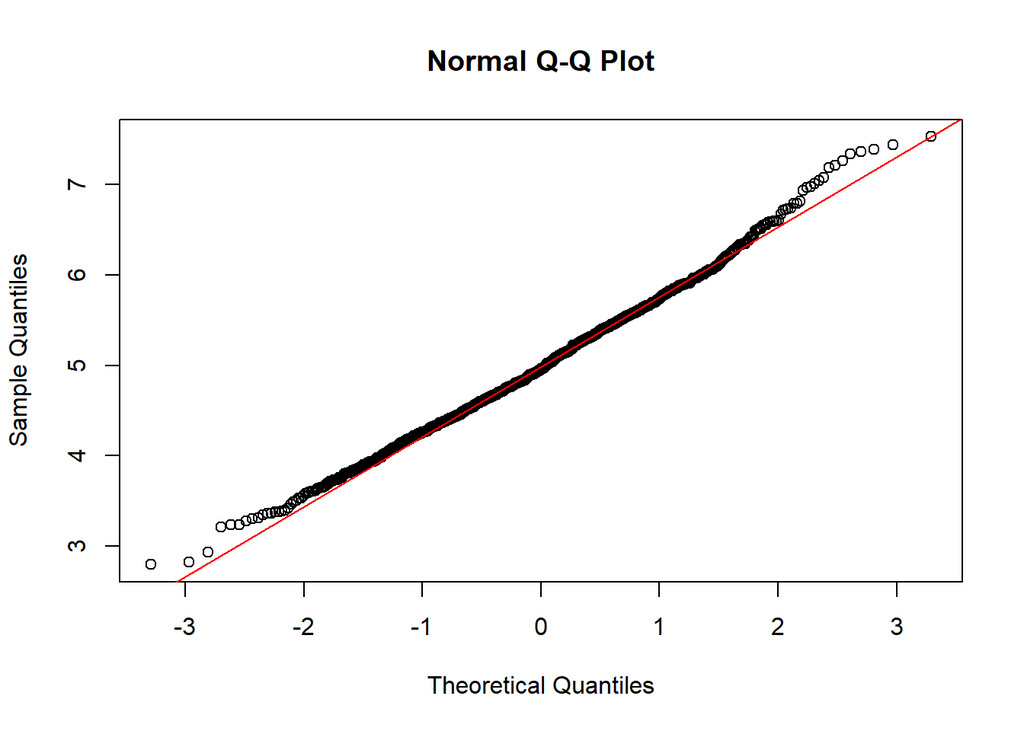

```r
qqnorm(means_exponentials); qqline(means_exponentials, col = 2)
```

We see graphically that the Central Limit Theorem did work out well with our simulations. The distribution of averages of 40 exponentials (black round shape on the graph) is very close to the normal distribution (in red on the graph)

In this exercise, we analyze the ToothGrowth data in the R datasets package. The data is a set of 60 observations, length of teeth in each of 10 guinea pigs at each of three dose levels of Vitamin C (0.5, 1 and 2 mg) with each of two delivery methods (orange juice (OJ) or vitamin C (VC)).

### Load the data and necessary packages

```r
if (!require("ggplot2")) {
    install.packages("ggplot2")}
library(ggplot2)
library(datasets)
data("ToothGrowth") #load data
```

### Basic exploration of the data

```r
dim(ToothGrowth)
```

```
## [1] 60  3
```

```r
str(ToothGrowth)
```

```
## 'data.frame':    60 obs. of  3 variables:
##  $ len : num  4.2 11.5 7.3 5.8 6.4 10 11.2 11.2 5.2 7 ...
##  $ supp: Factor w/ 2 levels "OJ","VC": 2 2 2 2 2 2 2 2 2 2 ...
##  $ dose: num  0.5 0.5 0.5 0.5 0.5 0.5 0.5 0.5 0.5 0.5 ...
```

```r
head(ToothGrowth, 15) #Display the first few rows of data
```

```
##     len supp dose
## 1   4.2   VC  0.5
## 2  11.5   VC  0.5
## 3   7.3   VC  0.5
## 4   5.8   VC  0.5
## 5   6.4   VC  0.5
## 6  10.0   VC  0.5
## 7  11.2   VC  0.5
## 8  11.2   VC  0.5
## 9   5.2   VC  0.5
## 10  7.0   VC  0.5
## 11 16.5   VC  1.0
## 12 16.5   VC  1.0
## 13 15.2   VC  1.0
## 14 17.3   VC  1.0
## 15 22.5   VC  1.0
```

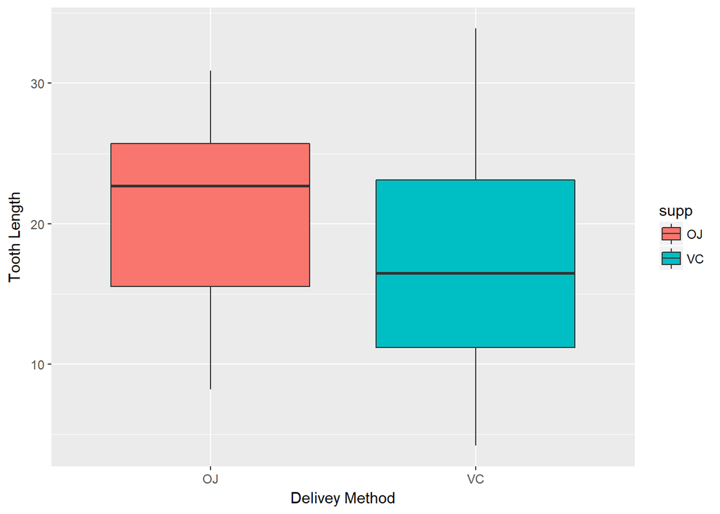

```r
g <- ggplot(ToothGrowth, aes(x = supp, y=len)) +
  geom_boxplot(aes(fill=supp)) + xlab("Delivey Method") + ylab("Tooth Length")
print(g) #Display a quick and dirty graph fo the data
```

### Summary of the data

```r
summary(ToothGrowth)
```

```
##       len        supp         dose
##  Min.   : 4.20   OJ:30   Min.   :0.500
##  1st Qu.:13.07   VC:30   1st Qu.:0.500
##  Median :19.25           Median :1.000
##  Mean   :18.81           Mean   :1.167
##  3rd Qu.:25.27           3rd Qu.:2.000
##  Max.   :33.90           Max.   :2.000
```

### Use confidence intervals and/or hypothesis tests to compare tooth growth by supp and dose

For less typing, variables will be stored to objects

```r
len<-ToothGrowth$len
supp<-ToothGrowth$supp
dose<-ToothGrowth$dose
```

```r
t.test(len~supp,data=ToothGrowth) # run t-test to compare tooth growth by supplement types
```

```
##
##  Welch Two Sample t-test
##
## data:  len by supp
## t = 1.9153, df = 55.309, p-value = 0.06063
## alternative hypothesis: true difference in means is not equal to 0
## 95 percent confidence interval:
##  -0.1710156  7.5710156
## sample estimates:
## mean in group OJ mean in group VC
##         20.66333         16.96333
```

The p-value of this test is 0.06063. Since the p-value is greater than 0.05 and the confidence interval of the test contains zero we have not enough evidence to reject the null hypothesis, we cannot assume that the means of delivery methods of the vitamin has en effect on tooth length.

Now we will look if there is a dose effect doing multiple comparisons.

```r
unique(ToothGrowth$dose) # give the dose values in the dataset
```

```
## [1] 0.5 1.0 2.0
```

There are 3 dose groups: 0.5, 1, and 2 to compare and 2 supplement groups, so we have to do 4 combination tests. We will consider that values are not paired and that variances are equal.

```r
pValues<-c(t.test(len[supp=="OJ"], len[supp=="VC"], paired = FALSE, var.equal = FALSE)$p.value, #compare both supplement  groups
           t.test(len[dose==2], len[dose==1], paired = FALSE, var.equal = TRUE)$p.value, #compare dose 2 to 1
           t.test(len[dose==1], len[dose==0.5], paired = FALSE, var.equal = TRUE)$p.value, #compare dose 1 to 0.5
           t.test(len[dose==2], len[dose==0.5], paired = FALSE, var.equal = TRUE)$p.value) # compare dose 2 to 0.5
pValues # print pValues of each t-test
```

```
## [1] 6.063451e-02 1.810829e-05 1.266297e-07 2.837553e-14
```

```r
round(p.adjust(pValues, method = "bonferroni"),3) # Controls Family-wise error rate via Bonferroni method, and display the adjusted p-values
```

```
## [1] 0.243 0.000 0.000 0.000
```

Three p-values are significant (p<0.05). There are the ones related to the pairwise tests of the doses.

```r
round(p.adjust(pValues, method = "BH"),3) # Controls False discovery rate via BH method, and display the adjusted p-values
```

```
## [1] 0.061 0.000 0.000 0.000
```

The same three t-tests leaded to significant p-values (p<0.05).

### State your conclusions and the assumptions needed for your conclusions

- Supply method has no effect on tooth growth according to t-test done on values from the 2 supply methods (p>0.05), assuming that variables are iid.
- Increasing the dose level leads to signitificant increased tooth growth (p<0.05), assuming that variables are iid.